# Final Project: Belief Change in Chatbot Conversations

Luan Chau

2026-05-08

## Introduction

This project develops an end-to-end R workflow to examine whether the effectiveness of chatbot-based refutation differed across specific AI misconceptions. The dataset originates from an experimental study in which participants were randomly assigned to one of three chatbot conditions: (1) a control non-refutational chatbot, (2) a simple refutation chatbot, and (3) an empathetic refutation chatbot. In each condition, participants engaged in four-turn conversations with the chatbot.

In the control condition, the chatbot did not attempt to correct participants’ misconceptions about AI. In the simple refutation condition, the chatbot explicitly identified participants’ beliefs as misconceptions and provided explanatory evidence to refute them. In the empathetic refutation condition, the chatbot first acknowledged and validated participants’ beliefs before gently explaining why the belief was a misconception and then providing corrective evidence.

Before and after interacting with the chatbot, participants rated their agreement with one of three AI misconceptions on a scale from 0 (“Totally disagree”) to 100 (“Totally agree”). Participants completed this procedure for each of the three misconceptions included in the study:

“AI works like the human brain.” “AI can be 100% objective.” “AI can understand and solve new problems the way the human brain can.”

The purpose of the study is to examine whether participants change their beliefs after conversing with the chatbot, particularly in the simple refutation and empathetic refutation conditions.

## Research Question

In the original study, we examined the effects of the three chatbot conditions on misconception reduction over time. We found that participants who interacted with the simple refutation and empathetic refutation chatbots showed substantial reductions in misconceptions, whereas participants in the control condition showed little to no change. However, we did not examine whether the magnitude of belief change was consistent across the three targeted misconceptions.

Therefore, in this project, I explored whether the effectiveness of chatbot-based refutation differed across specific AI misconceptions. In particular, I examined whether some misconceptions were more resistant to change than others following interactions with the simple refutation and empathetic refutation chatbots. By analyzing belief change at the misconception level, this project aimed to provide a more fine-grained understanding of how individuals respond to different forms of corrective chatbot interventions.

My research question is as follows: Do participants exhibit different levels of belief reduction across AI misconceptions after interacting with simple refutation and empathetic refutation chatbots?

## Hypotheses

1. Belief ratings will decrease from pretest to posttest in the simple refutation and empathetic refutation conditions across misconceptions.
2. Some misconceptions will show larger reductions in belief ratings than others following interactions with the simple refutation and empathetic refutation chatbots.
3. Misconceptions related to human-like thinking in AI may be more resistant to change than misconceptions related to AI bias or objectivity.

## Data Description

This project uses a deidentified dataset after a chatbot misconception intervention study. Each participant responds to three misconceptions at pre-test and post-test

The dataset contains: - ParticipantNo: The participant identification number (N = 120) - SelectedStyle: The chatbot condition to which the participant was assigned - PreSlider_1: Agreement pre-rating Misconception 1 (0-100) - PostSlider_1: Agreement post-rating Misconception 1 (0-100) - PreSlider_2: Agreement pre-rating Misconception 2 (0-100) - PostSlider_2: Agreement post-rating Misconception 2 (0-100) - PreSlider_3: Agreement pre-rating Misconception 3 (0-100) - PostSlider_3: Agreement post-rating Misconception 3 (0-100)

## Load and inspect the dataset

```r
#set working directory
setwd("C:/Users/admin/Documents/GitHub/EPSY5123-Final-Project-Luan-Chau/data")

#load data
chatbotdata <- read_csv2("chatbotdata.csv")
```

```
## ℹ Using "','" as decimal and "'.'" as grouping mark. Use `read_delim()` for more control.
```

```r
#inspect the data
head(chatbotdata)
```

```
## # A tibble: 6 × 8
##   ParticipantNo SelectedStyle PreSlider_1 PostSlider_1 PreSlider_2 PostSlider_2
##           <dbl> <chr>               <dbl>        <dbl>       <dbl>        <dbl>
## 1             1 empathetic             71           53          78           63
## 2             2 empathetic             29            0          24            0
## 3             3 empathetic             70           15          90           10
## 4             4 control                85           99          50           80
## 5             5 control                20           20          75           60
## 6             6 empathetic             40           34          72           21
## # ℹ 2 more variables: PreSlider_3 <dbl>, PostSlider_3 <dbl>
```

```r
summary(chatbotdata)
```

```
##  ParticipantNo    SelectedStyle       PreSlider_1     PostSlider_1
##  Min.   :  1.00   Length:120         Min.   :  0.0   Min.   :  0.00
##  1st Qu.: 30.75   Class :character   1st Qu.: 30.0   1st Qu.: 10.00
##  Median : 60.50   Mode  :character   Median : 70.0   Median : 25.50
##  Mean   : 60.50                      Mean   : 59.6   Mean   : 36.12
##  3rd Qu.: 90.25                      3rd Qu.: 82.0   3rd Qu.: 68.00
##  Max.   :120.00                      Max.   :100.0   Max.   :100.00
##   PreSlider_2      PostSlider_2     PreSlider_3      PostSlider_3
##  Min.   :  0.00   Min.   :  0.00   Min.   :  0.00   Min.   :  0.00
##  1st Qu.: 29.75   1st Qu.:  8.50   1st Qu.: 15.00   1st Qu.:  1.50
##  Median : 68.50   Median : 30.00   Median : 47.50   Median : 21.00
##  Mean   : 57.59   Mean   : 38.73   Mean   : 47.47   Mean   : 33.57
##  3rd Qu.: 80.50   3rd Qu.: 71.25   3rd Qu.: 80.00   3rd Qu.: 66.75
##  Max.   :100.00   Max.   :100.00   Max.   :100.00   Max.   :100.00
```

The dataset included 120 participants and contained pre- and post-interaction belief ratings for three AI misconceptions. Across misconceptions, mean belief ratings generally decreased from pre- to post-interaction, suggesting overall reductions in misconception endorsement following chatbot interaction.

Misconception 1 showed the highest average pre-interaction belief ratings (M = 59.60), followed by Misconception 2 (M = 57.59) and Misconception 3 (M = 47.47). Post-interaction belief ratings were lower across all misconceptions, with means ranging from 33.57 to 38.73. The wide ranges and quartile distributions indicated substantial variability in participants’ misconception beliefs and responsiveness to corrective information.

## Data wrangling: Reshape the data to long format for analysis and compute change scores

Because the study involved repeated belief ratings across multiple misconceptions and time points for each participant, the dataset was reshaped from wide format (the current format) to long format prior to analysis. Long format is more appropriate for repeated measures analyses because it organizes each observation as a separate row, allowing time (pre and post), misconception type, and chatbot condition to be modeled as variables rather than as separate columns.

This structure facilitates data visualization, descriptive statistics, and statistical modeling using repeated measures approaches such as mixed-effects models.

```r
chatbot_long <- chatbotdata %>%
  pivot_longer(
    cols = starts_with(c("PreSlider", "PostSlider")), #select all pretest and posttest belief rating columns
    names_to = c("Time", "Misconception"), # split the original column names into two new variables
    names_pattern = "(PreSlider|PostSlider)_(\\d)",# extract time point and misconception number from column names
    values_to = "BeliefRating" # store the belief rating values in one column
  ) %>%
  mutate(
    Time = recode(Time,
                  "PreSlider" = "Pre",
                  "PostSlider" = "Post"), # rename time labels to more simple names
    BeliefRating = as.numeric(BeliefRating), # convert belief ratings into numeric values

    Misconception = factor(Misconception), #convert misconception number into a categorical variable

    SelectedStyle = factor(SelectedStyle) # convert chatbot condition into a categorical variable
  )

glimpse(chatbot_long) # display the structure of the reshaped dataset
```

```
## Rows: 720
## Columns: 5
## $ ParticipantNo <dbl> 1, 1, 1, 1, 1, 1, 2, 2, 2, 2, 2, 2, 3, 3, 3, 3, 3, 3, 4,…
## $ SelectedStyle <fct> empathetic, empathetic, empathetic, empathetic, empathet…
## $ Time          <chr> "Pre", "Pre", "Pre", "Post", "Post", "Post", "Pre", "Pre…
## $ Misconception <fct> 1, 2, 3, 1, 2, 3, 1, 2, 3, 1, 2, 3, 1, 2, 3, 1, 2, 3, 1,…
## $ BeliefRating  <dbl> 71, 78, 66, 53, 63, 57, 29, 24, 0, 0, 0, 0, 70, 90, 15, …
```

```r
belief_change <- chatbot_long %>% # create a new dataset containing belief change scores
  select(ParticipantNo, SelectedStyle, Misconception, Time, BeliefRating) %>% # keep only relevant variables
  group_by(ParticipantNo, SelectedStyle, Misconception, Time) %>% # group data by participant, condition, misconception, and time
  summarise( # compute the mean belief rating for each grouped observation
    BeliefRating = mean(BeliefRating, na.rm = TRUE),
    .groups = "drop"
  ) %>%
  pivot_wider( # Reshape the data from long to wide format and create separate columns for Pre and Post belief ratings
    names_from = Time,
    values_from = BeliefRating
  ) %>%
  mutate( # compute belief reduction
    BeliefReduction = Pre - Post
  )

glimpse(belief_change) # display structure of the data frame
```

```
## Rows: 360
## Columns: 6
## $ ParticipantNo   <dbl> 1, 1, 1, 2, 2, 2, 3, 3, 3, 4, 4, 4, 5, 5, 5, 6, 6, 6, …
## $ SelectedStyle   <fct> empathetic, empathetic, empathetic, empathetic, empath…
## $ Misconception   <fct> 1, 2, 3, 1, 2, 3, 1, 2, 3, 1, 2, 3, 1, 2, 3, 1, 2, 3, …
## $ Post            <dbl> 53, 63, 57, 0, 0, 0, 15, 10, 15, 99, 80, 89, 20, 60, 1…
## $ Pre             <dbl> 71, 78, 66, 29, 24, 0, 70, 90, 15, 85, 50, 95, 20, 75,…
## $ BeliefReduction <dbl> 18, 15, 9, 29, 24, 0, 55, 80, 0, -14, -30, 6, 0, 15, 0…
```

## Descriptive statistics by condition and time

```r
chatbot_long %>%
  filter(!is.na(SelectedStyle)) %>%
  group_by(SelectedStyle, Misconception, Time) %>%
  summarise(
    MeanBelief = mean(BeliefRating, na.rm = TRUE),
    SDBelief = sd(BeliefRating, na.rm = TRUE),
    N = n(),
    .groups = "drop"
  ) %>%
  arrange(SelectedStyle, Misconception, desc(Time))
```

```
## # A tibble: 18 × 6
##    SelectedStyle Misconception Time  MeanBelief SDBelief     N
##    <fct>         <fct>         <chr>      <dbl>    <dbl> <int>
##  1 control       1             Pre         59.5     27.9    30
##  2 control       1             Post        57.8     29.0    30
##  3 control       2             Pre         70.2     23.9    30
##  4 control       2             Post        69.6     27.1    30
##  5 control       3             Pre         62.2     29.2    30
##  6 control       3             Post        60.0     29.7    30
##  7 empathetic    1             Pre         62.8     28.4    40
##  8 empathetic    1             Post        31.7     31.7    40
##  9 empathetic    2             Pre         56.4     33.8    40
## 10 empathetic    2             Post        29.0     28.1    40
## 11 empathetic    3             Pre         46.8     33.9    40
## 12 empathetic    3             Post        28.7     29.5    40
## 13 simple        1             Pre         57.1     29.9    50
## 14 simple        1             Post        26.6     29.6    50
## 15 simple        2             Pre         51.0     33.6    50
## 16 simple        2             Post        28       30.6    50
## 17 simple        3             Pre         39.2     35.6    50
## 18 simple        3             Post        21.6     29.6    50
```

Descriptive statistics suggested that misconceptions differed in their susceptibility to revision. For the simple refutation and empathetic refutation condition, Misconception 1 demonstrated the largest reductions in belief ratings, whereas Misconception 3 exhibited comparatively smaller reductions, suggesting greater resistance to change. In contrast, participants in the control condition showed minimal changes across all misconceptions.

Notably, the empathetic and simple refutation chatbots produced broadly similar patterns of belief reduction across misconception types, indicating that both forms of conversational refutation were effective in reducing misconception endorsement.

## Visualizations: Plotting belief change by condition, misconception, and time

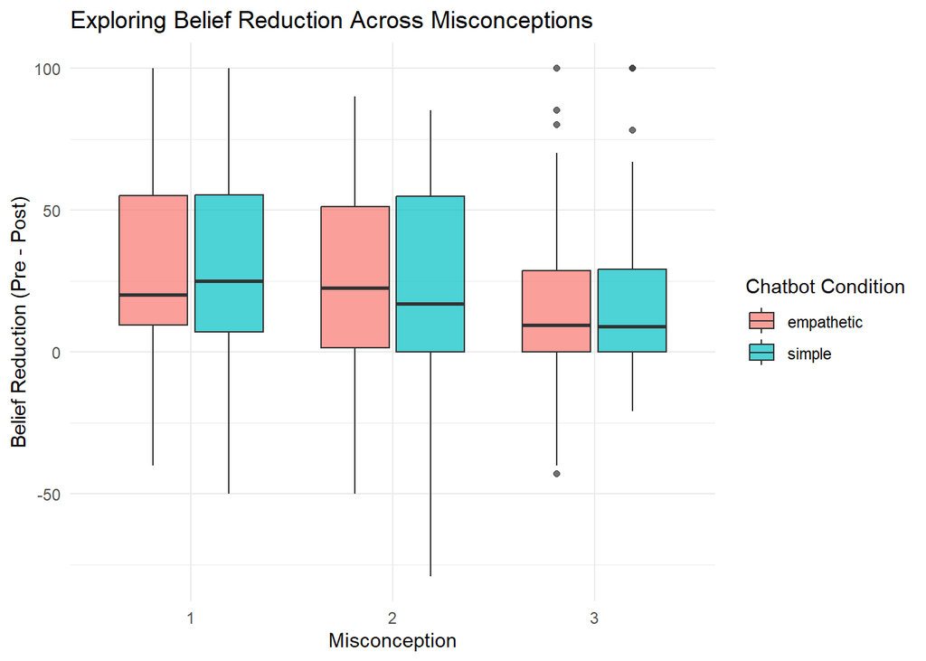

```r
ggplot(
  belief_change %>%
    filter(SelectedStyle != "control"),

  aes(x = Misconception,
      y = BeliefReduction,
      fill = SelectedStyle)
) +

  geom_boxplot(alpha = .70) +

  labs(
    title = "Exploring Belief Reduction Across Misconceptions",
    x = "Misconception",
    y = "Belief Reduction (Pre - Post)",
    fill = "Chatbot Condition"
  ) +

  theme_minimal()
```

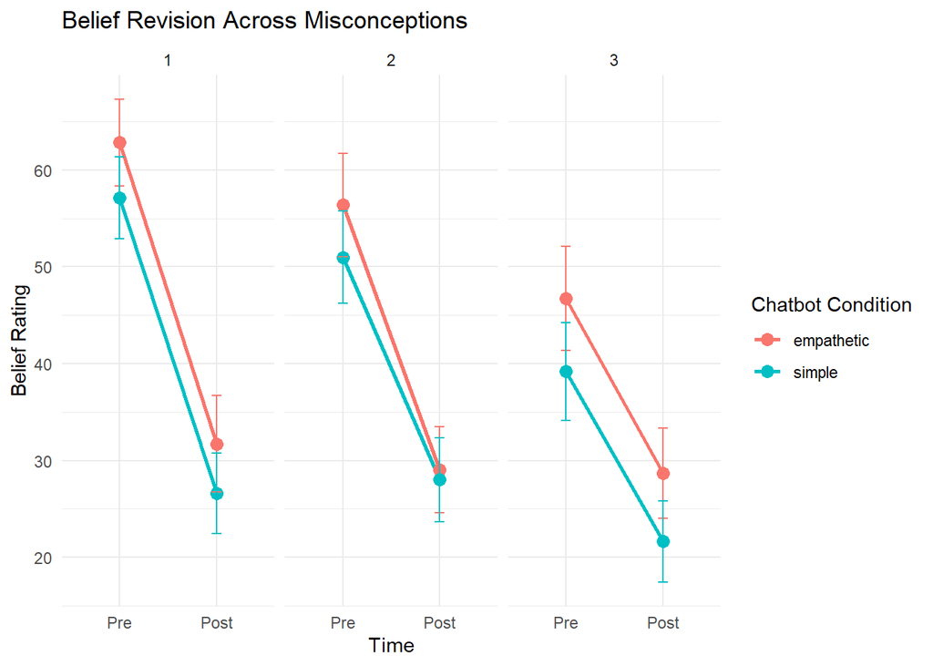

```r
ggplot(
  chatbot_long %>%
    filter(SelectedStyle != "control") %>%
    mutate(
      Time = factor(Time, levels = c("Pre", "Post"))
    ),

  aes(x = Time,
      y = BeliefRating,
      group = SelectedStyle,
      color = SelectedStyle)
) +

  stat_summary(fun = mean, geom = "line", linewidth = 1) +

  stat_summary(fun = mean, geom = "point", size = 3) +

  stat_summary(fun.data = mean_se,
               geom = "errorbar",
               width = .10) +

  facet_wrap(~ Misconception) +

  labs(
    title = "Belief Revision Across Misconceptions",
    x = "Time",
    y = "Belief Rating",
    color = "Chatbot Condition"
  ) +

  theme_minimal()
```

The line graph illustrates changes in misconception belief ratings across time, chatbot condition, and misconception type. Across all misconceptions, participants demonstrated lower belief ratings following interaction with the refutational chatbots. Both empathetic and simple refutation conditions showed substantial reductions in misconception endorsement and produced broadly similar patterns of change. However, the magnitude of belief revision varied across misconceptions. Misconception 1 demonstrated the largest reductions in belief ratings, whereas Misconception 3 exhibited comparatively smaller decreases, suggesting greater resistance to revision.

## Modeling

```r
misconception_fit <- linear_reg() %>%
  set_engine("lm") %>%
  fit(
    BeliefRating ~ Time * Misconception,
    data = chatbot_long
  )

misconception_fit
```

```
## parsnip model object
##
##
## Call:
## stats::lm(formula = BeliefRating ~ Time * Misconception, data = data)
##
## Coefficients:
##            (Intercept)                 TimePre          Misconception2
##                 36.117                  23.483                   2.617
##         Misconception3  TimePre:Misconception2  TimePre:Misconception3
##                 -2.550                  -4.625                  -9.583
```

```r
tab_model(misconception_fit)
```

|  | Dependent variable |  |  |
| --- | --- | --- | --- |
| Predictors | Estimates | CI | p |
| (Intercept) | 36.12 | 30.28 – 41.95 | **<0.001** |
| Time [Pre] | 23.48 | 15.23 – 31.74 | **<0.001** |
| Misconception [2] | 2.62 | -5.64 – 10.87 | 0.534 |
| Misconception [3] | -2.55 | -10.80 – 5.70 | 0.544 |
| Time [Pre] × Misconception [2] | -4.63 | -16.30 – 7.05 | 0.437 |
| Time [Pre] × Misconception [3] | -9.58 | -21.25 – 2.09 | 0.107 |
| Observations | 720 |  |  |
| R<sup>2</sup> / R<sup>2</sup> adjusted | 0.090 / 0.084 |  |  |

Regression analyses examined whether belief revision differed across misconception types. Results indicated a significant overall effect of time, such that participants reported substantially higher belief ratings at pre-test than at post-test, b = 23.48, 95% CI [15.23, 31.74], p < .001, suggesting significant reductions in misconception endorsement following chatbot interaction. No significant main effects of misconception type were observed at post-test, indicating that post-interaction belief ratings were generally comparable across misconceptions. Interaction effects between time and misconception type were also not statistically significant.

However, Misconception 3 demonstrated a comparatively larger negative interaction coefficient, b = -9.58, 95% CI [-21.25, 2.09], p = .107, suggesting that this misconception may have been somewhat more resistant to revision than Misconception 1. This pattern was broadly consistent with the descriptive statistics and visualizations, which showed comparatively smaller reductions in belief ratings for Misconception 3.

Overall, the findings suggest that chatbot interaction was effective in reducing AI misconception beliefs, although the magnitude of belief revision may vary somewhat across misconception types.